# Notebook

### Web Information Retrieval and Data Mining - Assignment 3

```
Student: van de Water, Robin (1503618)
```

#### Answer 1.1, Baseline (4p)

- Dense network, at least 3 layers, shaped like a pyramid
  - Last layer: 10 nodes, sigmoid.
  - Loss: categorical cross-entropy. Metric: accuracy
- No preprocessing, regularization. Get at least 70% accuracy.
- Explain design decisions. Discuss performance.
  - Does it overfit (large/growing gap between loss and val_loss)?

[output not shown]

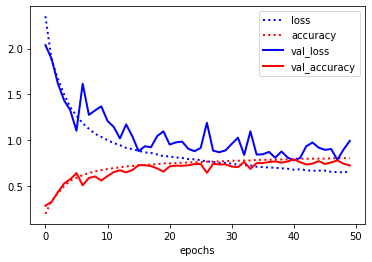

```
Model: "sequential_15"
_________________________________________________________________
Layer (type)                 Output Shape              Param #
=================================================================
reshape_7 (Reshape)          (None, 3072)              0
_________________________________________________________________
dense_59 (Dense)             (None, 2000)              6146000
_________________________________________________________________
dense_60 (Dense)             (None, 500)               1000500
_________________________________________________________________
dense_61 (Dense)             (None, 250)               125250
_________________________________________________________________
dense_62 (Dense)             (None, 125)               31375
_________________________________________________________________
dense_63 (Dense)             (None, 10)                1260
=================================================================
Total params: 7,304,385
Trainable params: 7,304,385
Non-trainable params: 0
_________________________________________________________________
None
def build_model_1_1():
  base_size = 2000
  inputs = 3072
  model = models.Sequential()

  #Input for data set
  model.add(layers.Reshape((inputs,), input_shape=(32,32,3)))

  #Pyramid shaped dense layers
  model.add(layers.Dense(base_size, activation='relu'))
  model.add(layers.Dense(base_size/4, activation='relu', ))
  model.add(layers.Dense(base_size/8, activation='relu', ))
  model.add(layers.Dense(base_size/16, activation='relu', ))

  #Output
  model.add(layers.Dense(10, activation='softmax'))

  #Compile model
  model.compile(optimizer='rmsprop',
                loss='categorical_crossentropy',
                metrics=['accuracy'])
  return model
```

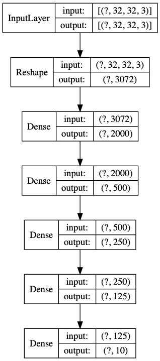

#### Answer 1.2, Preprocess (2p)

- Convert images to greyscale, other preprocessing optional.
  - Input shape should be (32,32,1)
- Explain design decisions. Is it better? Why (not)?
  - Color information is likely not so useful for classification. Greyscale makes the network smaller, less parameters to learn, less likely to overfit.

```
This makes sense: for processing the shapes of numbers, we don't need color. Finetuning this model could help it improve even more, I would specifically try a smaller base_size and change up the pyramid shape. (length: 210)

Max val score: 80.57%
```

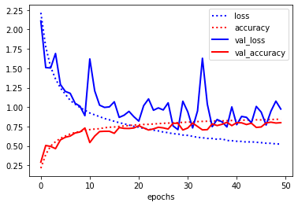

```
Model: "sequential_24"
_________________________________________________________________
Layer (type)                 Output Shape              Param #
=================================================================
reshape_16 (Reshape)         (None, 1024)              0
_________________________________________________________________
dense_104 (Dense)            (None, 2000)              2050000
_________________________________________________________________
dense_105 (Dense)            (None, 500)               1000500
_________________________________________________________________
dense_106 (Dense)            (None, 250)               125250
_________________________________________________________________
dense_107 (Dense)            (None, 125)               31375
_________________________________________________________________
dense_108 (Dense)            (None, 10)                1260
=================================================================
Total params: 3,208,385
Trainable params: 3,208,385
Non-trainable params: 0
_________________________________________________________________
None
def build_model_1_2():
  base_size = 2000
  inputs = 1024
  model = models.Sequential()

  #Input for data set
  model.add(layers.Reshape((inputs,), input_shape=(32,32,1)))

  #Pyramid shaped dense layers
  model.add(layers.Dense(base_size, activation='relu'))
  model.add(layers.Dense(base_size/4, activation='relu', ))
  model.add(layers.Dense(base_size/8, activation='relu', ))
  model.add(layers.Dense(base_size/16, activation='relu', ))

  #Output
  model.add(layers.Dense(10, activation='softmax'))

  #Compile model
  model.compile(optimizer='rmsprop',
                loss='categorical_crossentropy',
                metrics=['accuracy'])
  return model
```

#### Answer 1.3, Tune (4p)

- Regularize the model. What works best?
  - Should consider batch normalization, dropout, l1/l2 regularization (or Nesterov)
- Tune other hyperparameters (e.g. learning rate, batch size,...) as you see fit.
  - At least consider tuning learning rate, ideally also momentum, decay, other optimizers
- Explain your findings and final design decisions. Discuss the results.
  - Should be better, at least it shouldn't overfit

[output not shown]

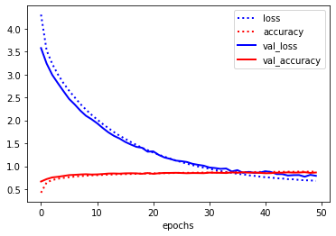

```
def build_model_1_3():
  model = models.Sequential()

  # Changed this to reflect the dimensions of the preprocessed data set
  inputs = 1024
  base_layer = 2000
  kernel_regularizer = regularizers.l2(0.001)
  model.add(layers.Reshape((inputs,), input_shape=(32,32,1)))
  model.add(layers.BatchNormalization())
  model.add(layers.Dense(base_layer, activation='relu', kernel_regularizer=kernel_regularizer))
  model.add(layers.Dropout(rate = 0.3, noise_shape=None, seed=None))
  model.add(layers.Dense(base_layer/4, activation='relu', kernel_regularizer=kernel_regularizer))
  model.add(layers.Dropout(rate = 0.2, noise_shape=None, seed=None))
  model.add(layers.Dense(base_layer/8, activation='relu', kernel_regularizer=kernel_regularizer ))
  model.add(layers.BatchNormalization())
  model.add(layers.Dense(base_layer/16, activation='relu', kernel_regularizer=kernel_regularizer))
  model.add(layers.Dropout(rate = 0.1, noise_shape=None, seed=None))
  model.add(layers.BatchNormalization())
  model.add(layers.Dense(10, activation='softmax'))

  adam = tf.keras.optimizers.Adam()
  sgd = tf.keras.optimizers.SGD(lr=0.01, momentum=0.7, nesterov=True)
  model.compile(optimizer=sgd,
                loss='categorical_crossentropy',
                metrics=['accuracy'])
  return model
```

#### Answer 2.1, ConvNet (7p)

- Build a sequential ConvNet, get at least 90% accuracy.
  - Conv2D layers, input shape (32,32,1)
  - Consider using blocks of Conv2D layers with maxpooling in between
  - Use zero-padding in Conv2D layers because the images are small
  - At least one dense hidden layer and dense output layer (sigmoid)
  - Consider adding batch normalization, dropout
  - Consider small dropout rates in beginning, larger dropout rates later in network
  - Consider other optimizers and tuning learning rate, momentum,...
- Explain what you did and why (800 chars). Is it working well?
  - Should be quite elaborate and sensible

[output not shown]

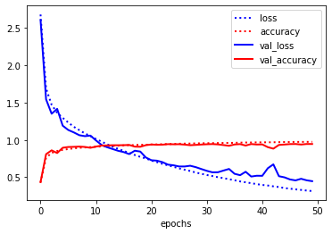

```
Model: "sequential_59"
_________________________________________________________________
Layer (type)                 Output Shape              Param #
=================================================================
conv2d_40 (Conv2D)           (None, 32, 32, 32)        320
_________________________________________________________________
batch_normalization_82 (Batc (None, 32, 32, 32)        128
_________________________________________________________________
max_pooling2d_24 (MaxPooling (None, 16, 16, 32)        0
_________________________________________________________________
dropout_110 (Dropout)        (None, 16, 16, 32)        0
_________________________________________________________________
conv2d_41 (Conv2D)           (None, 16, 16, 32)        9248
_________________________________________________________________
batch_normalization_83 (Batc (None, 16, 16, 32)        128
_________________________________________________________________
conv2d_42 (Conv2D)           (None, 16, 16, 64)        18496
_________________________________________________________________
batch_normalization_84 (Batc (None, 16, 16, 64)        256
_________________________________________________________________
max_pooling2d_25 (MaxPooling (None, 8, 8, 64)          0
_________________________________________________________________
dropout_111 (Dropout)        (None, 8, 8, 64)          0
_________________________________________________________________
conv2d_43 (Conv2D)           (None, 8, 8, 128)         73856
_________________________________________________________________
batch_normalization_85 (Batc (None, 8, 8, 128)         512
_________________________________________________________________
conv2d_44 (Conv2D)           (None, 8, 8, 256)         295168
_________________________________________________________________
batch_normalization_86 (Batc (None, 8, 8, 256)         1024
_________________________________________________________________
max_pooling2d_26 (MaxPooling (None, 4, 4, 256)         0
_________________________________________________________________
dropout_112 (Dropout)        (None, 4, 4, 256)         0
_________________________________________________________________
flatten_9 (Flatten)          (None, 4096)              0
_________________________________________________________________
dense_276 (Dense)            (None, 256)               1048832
_________________________________________________________________
```

[output cut: 35 more lines]

```
  model.add(layers.MaxPooling2D((2, 2)))
  model.add(layers.Dropout(0.3))
  model.add(layers.Flatten())
  model.add(layers.Dense(256, activation='relu', kernel_regularizer=kernel_regularizer))
  model.add(layers.BatchNormalization())
  model.add(layers.Dropout(0.2))
  model.add(layers.Dense(128, activation='relu', kernel_regularizer=kernel_regularizer))
  model.add(layers.BatchNormalization())

  model.add(layers.Dense(10, activation='softmax'))
  sgd = tf.keras.optimizers.SGD(lr=0.01, momentum=0.7, nesterov=True)
  model.compile(optimizer=sgd,
                loss='categorical_crossentropy',
                metrics=['accuracy'])
  return model
```

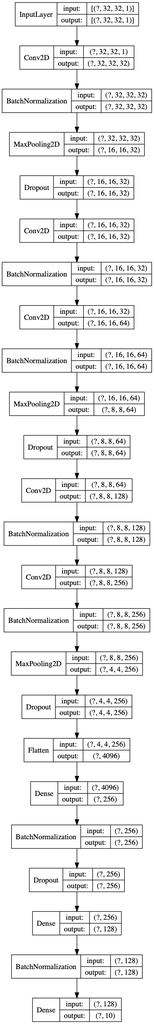

#### Answer 2.2, Data Augmentation (3p)

- Augment the preprocessed training data.
  - Use small variations (small shifts up-down, left-right) of flips becasue the images are small
  - Large shifts and rotations distort the image too much
- Explain what you did and why. Discuss the performance of the model.

[output not shown]

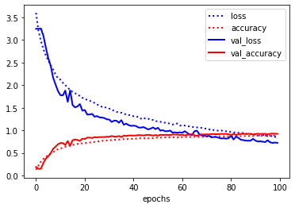

```
IDG = ImageDataGenerator(width_shift_range = width, height_shift_range = height, rotation_range = rotation, zoom_range = zoom, horizontal_flip = flip)
```

#### Answer 3.1, Misclassifications (2p)

[output not shown]

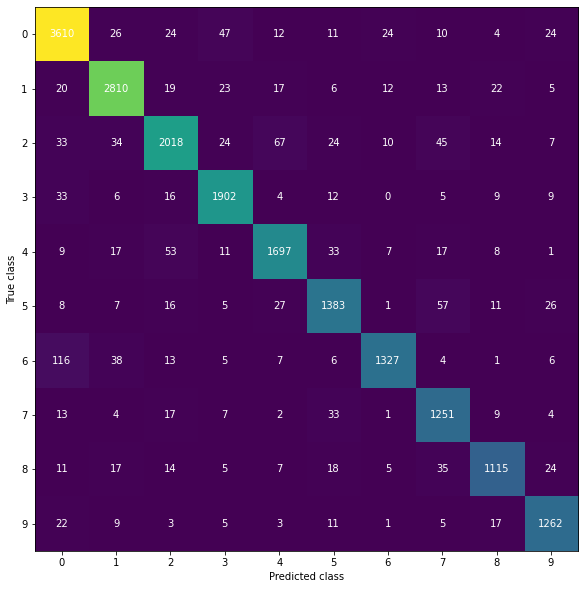

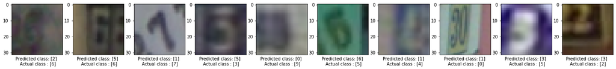

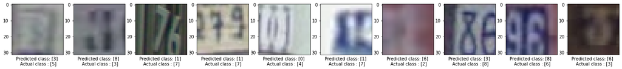

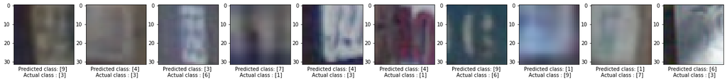

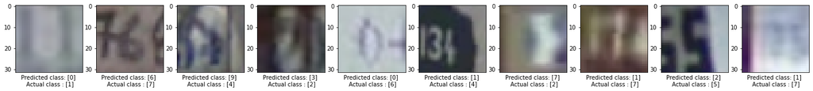

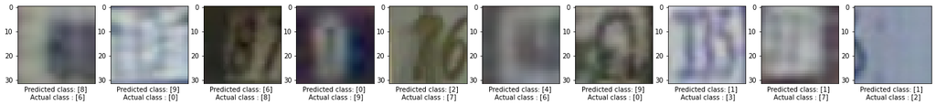

#### Answer 3.2, Activations (4p)

- Retrieve and visualize the activations for one example
- For every filter for different convolutional layers (at different depths in the network).
- Give an explanation. Is your model indeed learning something useful?
  - Should detect edges etc in first layers, higher-order object (e.g. interesting regions) in deeper layers.

[output not shown]

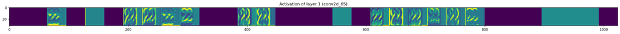

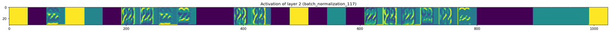

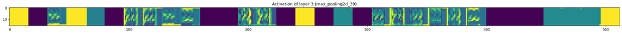

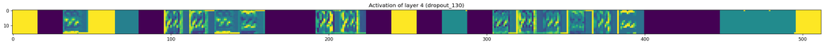

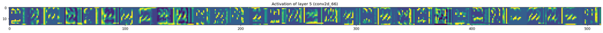

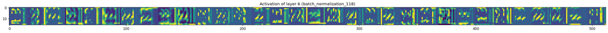

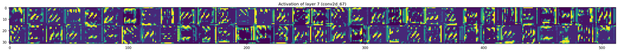

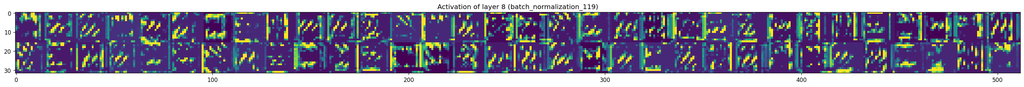

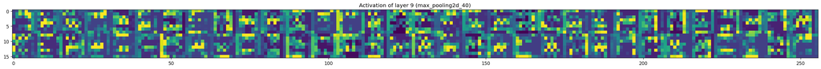

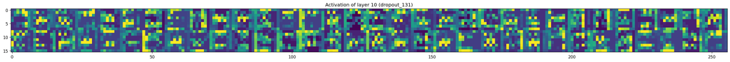

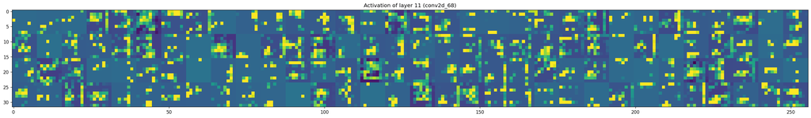

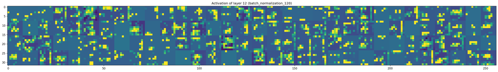

[3 more figures not shown]

#### Answer 3.3, Class activation map (4p)

- Show a class activation map for your last convolutional layer
- Superimpose the activation map over the image, or plot side by side
  - Should make sense, detect interesting regions to classify the number

```
Model: "sequential_64"
_________________________________________________________________
Layer (type)                 Output Shape              Param #
=================================================================
conv2d_65 (Conv2D)           (None, 32, 32, 32)        320
_________________________________________________________________
batch_normalization_117 (Bat (None, 32, 32, 32)        128
_________________________________________________________________
max_pooling2d_39 (MaxPooling (None, 16, 16, 32)        0
_________________________________________________________________
dropout_130 (Dropout)        (None, 16, 16, 32)        0
_________________________________________________________________
conv2d_66 (Conv2D)           (None, 16, 16, 32)        9248
_________________________________________________________________
batch_normalization_118 (Bat (None, 16, 16, 32)        128
_________________________________________________________________
conv2d_67 (Conv2D)           (None, 16, 16, 64)        18496
_________________________________________________________________
batch_normalization_119 (Bat (None, 16, 16, 64)        256
_________________________________________________________________
max_pooling2d_40 (MaxPooling (None, 8, 8, 64)          0
_________________________________________________________________
dropout_131 (Dropout)        (None, 8, 8, 64)          0
_________________________________________________________________
conv2d_68 (Conv2D)           (None, 8, 8, 128)         73856
_________________________________________________________________
batch_normalization_120 (Bat (None, 8, 8, 128)         512
_________________________________________________________________
conv2d_69 (Conv2D)           (None, 8, 8, 256)         295168
_________________________________________________________________
batch_normalization_121 (Bat (None, 8, 8, 256)         1024
_________________________________________________________________
max_pooling2d_41 (MaxPooling (None, 4, 4, 256)         0
_________________________________________________________________
dropout_132 (Dropout)        (None, 4, 4, 256)         0
_________________________________________________________________
flatten_14 (Flatten)         (None, 4096)              0
_________________________________________________________________
dense_291 (Dense)            (None, 256)               1048832
_________________________________________________________________
```

[output cut: 56 more lines]

```
    heatmap = cv2.resize(heatmap, (32, 32))

    #Convert to RGB
    heatmap = np.uint8(255*heatmap)

    #Apply heatmap
    heatmap = cv2.applyColorMap(heatmap, cv2.COLORMAP_JET)
    heatmap = heatmap / 255

    #Apply overlay
    result_image = 1 * imageoverlay_converted + 0.2 * heatmap
    axes[classes].imshow(result_image)
    axes[classes].set_xlabel('Class {}'.format((classes+1)%10))

  plt.show(block=False)
```

[figure not shown]

#### Answer 4.1, Fast feature extraction (5p)

- Import the VGG16 model, pretrained on ImageNet
- Freeze convolutional base, adds a dense layer
- Consider unfreezing the last few convolutional layers and evaluate whether that works better
  - Check if they do. It is very likely to help.
- Discuss the observed performance
  - Should get around 80% accuracy

[output not shown]

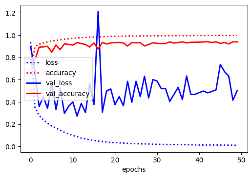

```
Model: "sequential_3"
_________________________________________________________________
Layer (type)                 Output Shape              Param #
=================================================================
vgg16 (Model)                (None, 1, 1, 512)         14714688
_________________________________________________________________
flatten_3 (Flatten)          (None, 512)               0
_________________________________________________________________
dropout_3 (Dropout)          (None, 512)               0
_________________________________________________________________
dense_6 (Dense)              (None, 256)               131328
_________________________________________________________________
batch_normalization_3 (Batch (None, 256)               1024
_________________________________________________________________
dropout_4 (Dropout)          (None, 256)               0
_________________________________________________________________
dense_7 (Dense)              (None, 10)                2570
=================================================================
Total params: 14,849,610
Trainable params: 3,969,546
Non-trainable params: 10,880,064
_________________________________________________________________
None
def build_model_4_1():
  vgg16 = tf.keras.applications.vgg16.VGG16(include_top=False, weights='imagenet', input_shape=(32,32,3), pooling=None)
  model = models.Sequential()
  vgg16.summary()

  for layer in vgg16.layers:
    if layer.name == 'block5_conv1' or layer.name=='block4_conv1' or layer.name=='block3_conv1':
        layer.trainable = True
    else:
        layer.trainable = False
  model.add(vgg16)

  model.add(layers.Flatten())
  # Added some simple extra layers to improve results
  model.add(layers.Dropout(0.2))
  model.add(layers.Dense(256, activation='relu'))
  model.add(layers.BatchNormalization())
  model.add(layers.Dropout(0.1))
  model.add(layers.Dense(10, activation='softmax'))
  model.compile(optimizer='rmsprop',
                loss='categorical_crossentropy',
                metrics=['accuracy'])
  return model
```

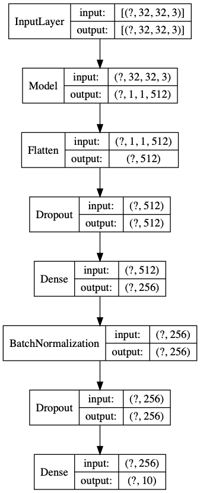

#### Answer 4.2, Embeddings (5p)

- Generate embeddings with the trained convolutional part of model_4_1 (without the dense layer)
- Embed the training and test data and store them to disk
- Build and evaluate a pipeline on the embedded data
  - Check if pipeline makes sense (e.g. use models that can handle many dimensions)
- Describe what you did and what you observed (max 800 chars).
  - Consider different models, preprocessing, tuning, etc.
  - Check performance (see original Submission.html) when in doubt. We did not run all the evaluations because it takes too long, and the output is ill-defined.

```
All in all, I think I stored the wrong embeddings for this assignment to do correct predictions. I do not see any other way that it would be feasible to store embeddings, however as that would involve enormous amounts of data. (length: 227)

Pipeline(steps=[('Scaler', Normalizer()),
                ('Classifier', SVC(max_iter=1000, verbose=True))])
def store_embeddings():
  """ Stores all necessary embeddings to file
  """
  embedding_model = load_model_from_file(base_dir, "model_4_1", extension='.h5')
  embedding_model.summary()
  result_train = embedding_model.predict(x = X_train, batch_size = 256, verbose=1)
  result_test = embedding_model.predict(x = X_test, batch_size = 256, verbose=1)
  result_validate = embedding_model.predict(x = X_val, batch_size = 256, verbose=1)
  print(result_train[1])
  store_embedding(result_train, 'train_results')
  store_embedding(result_test, 'test_results')
  store_embedding(result_validate, 'validate_results')

def evaluation_4_2(X_train, y_train, X_test, y_test):
  """ Runs 'evaluate_pipeline' with embedded versions of the input data
  and returns the accuracy.
  """
  score = evaluate_pipeline(generate_pipeline(), X_train = X_train, y_train = y_train, X_test = X_test, y_test = y_test)
  return score
```

```
Running time: 28.81 seconds
Last modified: May 26, 2020
scikit-learn version: 0.23.1
```